# Global AI Hub - Veri Görselleştirme

# **VERİ GÖRSELLEŞTİRME - WORLD HAPPINESS REPORT DATA**

Dünya Mutluluk Raporu, küresel mutluluğun durumuna ilişkin önemli bir araştırmadır. Ekonomi, psikoloji, anket analizi, ulusal istatistik, sağlık, kamu politikası ve daha fazlası gibi alanlarda önde gelen uzmanlar, ulusların ilerlemesini değerlendirmek için refah ölçümlerinin nasıl etkili bir şekilde kullanılabileceğini anlatıyor. Raporlar, günümüz dünyasında mutluluğun durumunu gözden geçirmekte ve yeni mutluluk biliminin mutluluktaki kişisel ve ulusal farklılıkları nasıl açıkladığını göstermektedir.

Mutluluk puanları ve sıralamaları, Gallup Dünya Anketinden alınan verileri kullanır. Mutluluk puanını izleyen sütunlar, ekonomik üretim, sosyal destek, yaşam beklentisi, özgürlük, yolsuzluğun olmaması ve cömertlik olmak üzere altı faktörün her birinin, her ülkede yaşam değerlendirmelerini Distopya’dakinden daha yüksek hale getirmeye ne ölçüde katkıda bulunduğunu tahmin ediyor.

# **BÖLÜM 1) VERİ OKUTMA VE ÖN İŞLEME**

```r
#KÜTÜPHANELER
library(corrplot)
library(stringr)
library(ggplot2)
library(dplyr)
library(arm)
library(ggrepel)
library(RColorBrewer)
library(GGally)
library(tidyr)
library(egg)
library(ggExtra)
library(Hmisc)
```

```r
library(readr)
data <- read_csv("C:/Users/ThinkPad/Desktop/world-happiness-report.csv")
colnames(data) <- data %>% colnames() %>% str_replace_all(" ","_") #değişkenlerin ismini düzeltelim.
data$year <- as.factor(data$year)
```

| **Değişken Adı** | **Açıklama** |
| --- | --- |
| Country name | Ülke Adı |
| Year | Yıl |
| Life Ladder | Yaşam Merdiveni |
| Log GDP per capita | Kişi başına düşen GSYİH |
| Social support | Sosyal Destek |
| Healthy life expectancy at birth | Doğumda Sağlıklı Yaşam Beklentisi |
| Freedom to make life choices | Yaşam Seçimlerini Yapma Özgürlüğü |
| Generosity | Cömertlik |
| Perceptions of corruption | Yolsuzluk Algıları |
| Positive affect | Olumlu Etki |
| Negative affect | Olumsuz Etki |

- **Gözlem sayısı:** 1949
- **Değişken sayısı:** 11

[Kaynak; World Happiness Report- Kaggle](https://www.kaggle.com/ajaypalsinghlo/world-happiness-report-2021?select=world-happiness-report.csv)

## **1.1 VERİ SETİNİN ÖZETİ**

```r
summary(data)
```

```
##  Country_name            year       Life_Ladder    Log_GDP_per_capita
##  Length:1949        2017   : 147   Min.   :2.375   Min.   : 6.635
##  Class :character   2011   : 146   1st Qu.:4.640   1st Qu.: 8.464
##  Mode  :character   2014   : 145   Median :5.386   Median : 9.460
##                     2019   : 144   Mean   :5.467   Mean   : 9.368
##                     2015   : 143   3rd Qu.:6.283   3rd Qu.:10.353
##                     2012   : 142   Max.   :8.019   Max.   :11.648
##                     (Other):1082                   NA's   :36
##  Social_support   Healthy_life_expectancy_at_birth Freedom_to_make_life_choices
##  Min.   :0.2900   Min.   :32.30                    Min.   :0.2580
##  1st Qu.:0.7498   1st Qu.:58.69                    1st Qu.:0.6470
##  Median :0.8355   Median :65.20                    Median :0.7630
##  Mean   :0.8126   Mean   :63.36                    Mean   :0.7426
##  3rd Qu.:0.9050   3rd Qu.:68.59                    3rd Qu.:0.8560
##  Max.   :0.9870   Max.   :77.10                    Max.   :0.9850
##  NA's   :13       NA's   :55                       NA's   :32
##    Generosity      Perceptions_of_corruption Positive_affect  Negative_affect
##  Min.   :-0.3350   Min.   :0.0350            Min.   :0.3220   Min.   :0.0830
##  1st Qu.:-0.1130   1st Qu.:0.6900            1st Qu.:0.6255   1st Qu.:0.2060
##  Median :-0.0255   Median :0.8020            Median :0.7220   Median :0.2580
##  Mean   : 0.0001   Mean   :0.7471            Mean   :0.7100   Mean   :0.2685
##  3rd Qu.: 0.0910   3rd Qu.:0.8720            3rd Qu.:0.7990   3rd Qu.:0.3200
##  Max.   : 0.6980   Max.   :0.9830            Max.   :0.9440   Max.   :0.7050
##  NA's   :89        NA's   :110               NA's   :22       NA's   :16
```

Özeti inceleyelim. Veri setimiz 11 değişken ve 1949 gözlemden oluşmaktadır. Counrty_name değişkeni karakter, year değişkeni de faktör olarak tanımlanmıştır, onun dışında kalan tüm değişkenler sayısaldır. 8 değişkende toplam 373 eksik gözlemler bulunmaktadır.

# **BÖLÜM 2) VERİ GÖRSELLEŞTİRME**

## **2.1 HİSTOGRAM GRAFİĞİ**

Aşağıdaki toplu grafikte veri setimizdeki tüm sayısal değişkenlerin histogram grafikleri vardır. Histogramlar, değerlerin nerede yoğunlaştığını, uç noktaların neler olduğunu ve veri kümesinde herhangi bir boşluk veya olağandışı değerler olup olmadığı konusunda bir tahmin verir. Bu grafiklere bakarak normal dağılıma sahip olup olmadıkları hakkında bilgi sahibi olabiliriz.

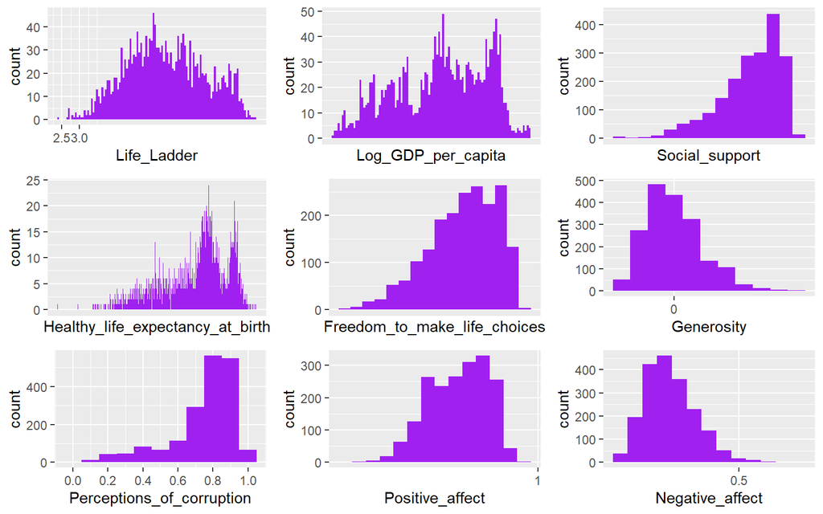

## **2.2 SAÇILIM GRAFİĞİ (SCATTER PLOT)**

Bir saçılım grafiği, iki sayısal değişken arasındaki ilişkiyi dağınık noktalar şeklinde çizmek için kullanılır. Grafikteki her nokta tek bir gözlemi temsil edecek şekilde gösterilir.

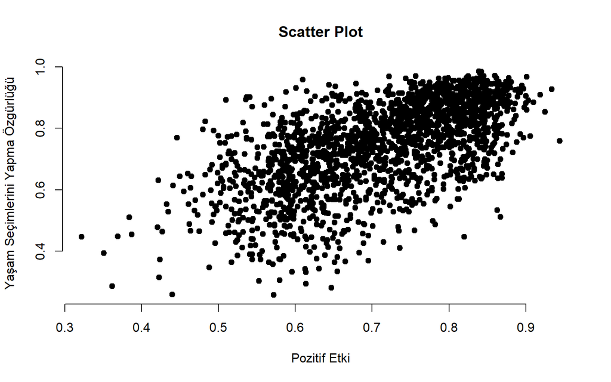

```r
a1 <- plot(data$Positive_affect, data$Freedom_to_make_life_choices, main = "Scatter Plot",
     xlab = "Pozitif Etki", ylab = "Yaşam Seçimlerini Yapma Özgürlüğü", pch = 19, frame = FALSE)
```

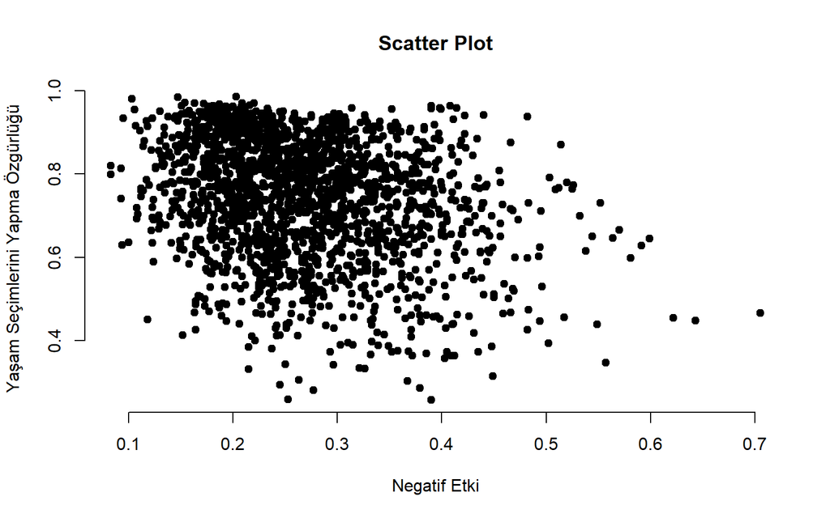

```r
a2 <- plot(data$Negative_affect, data$Freedom_to_make_life_choices, main = "Scatter Plot",
     xlab = "Negatif Etki", ylab = "Yaşam Seçimlerini Yapma Özgürlüğü", pch = 19, frame = FALSE)
```

İki farklı scatter plot çizdirdik. Bu grafiklere bakarak Yaşam Seçimlerini Yapma Özgürlüğünün (Freedom_to_make_life_choices) Pozitif veya Negatif bir etki oluşturup oluşturmadığını inceleyebiliyoruz. Yaşam Seçimlerini Yapma Özgürlüğü arttıkça pozitif etki artmıştır, negatif etki azalmıştır. Bu da insanların mutluluklarında yaşamdaki seçimlerini özgürce yapmanın büyük bir etkisi olduğunu gösterir.

### **a) En Mutlu Batı Avrupa Ülkeleri**

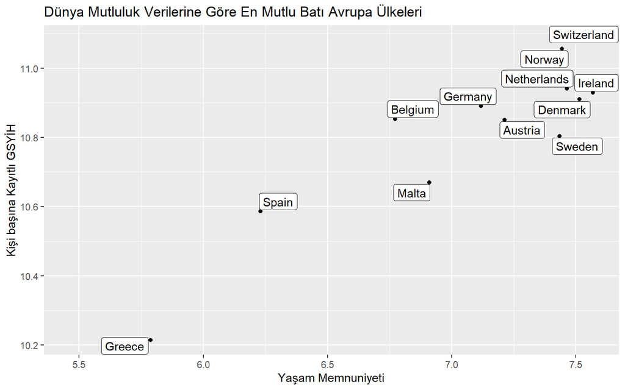

```r
p1 <-ggplot(data = data %>%
             filter(Country_name==c("Finland","Denmark","Switzerland","Iceland","Netherlands","Norway","Sweden","Luxembourg","Austria","Germany", "Ireland","United Kingdom","Belgium","France", "Malta","Spain","Italy","Cyprus","Portugal","Greece", "North Cyprus") & Life_Ladder>5))+
  geom_point(mapping = aes(x=Life_Ladder,
                           y=Log_GDP_per_capita))+
  ggtitle("Dünya Mutluluk Verilerine Göre En Mutlu Batı Avrupa Ülkeleri")+
  xlab("Yaşam Memnuniyeti")+
  ylab("Kişi başına Kayıtlı GSYİH")+
  geom_label_repel(aes(x=Life_Ladder,
                       y=Log_GDP_per_capita,
                       label=Country_name),
                   box.padding = 0.05,
                   point.padding = 0.1,
                   max.overlaps = 30,
                   segment.color = 'grey50')
p1
```

Baktığımızda 21 tane Batı Avrupa Ülkesinin 12 tanesi yani %57’si mutlu çıkmıştır. Yunanistan en az mutlu, İrlanda ise en mutlu ülke çıkmıştır.

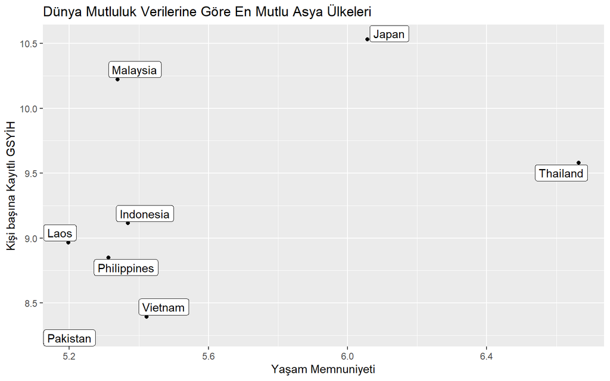

```r
p2 <-ggplot(data = data %>%
             filter(Country_name==c("Singapore","Thailand","Philippines","Vietnam","Malaysia","Indonesia","Laos","Cambodia","Myanmar","China", "Hong Kong S.A.R. of China","Mongolia","South Korea","Japan", "Taiwan Province of China","Nepal","Maldives","Bangladesh","Pakistan","Sri Lanka", "India","Afghanistan") & Life_Ladder>5))+
  geom_point(mapping = aes(x=Life_Ladder,
                           y=Log_GDP_per_capita))+
  ggtitle("Dünya Mutluluk Verilerine Göre En Mutlu Asya Ülkeleri")+
  xlab("Yaşam Memnuniyeti")+
  ylab("Kişi başına Kayıtlı GSYİH")+
  geom_label_repel(aes(x=Life_Ladder,
                       y=Log_GDP_per_capita,
                       label=Country_name),
                   box.padding = 0.05,
                   point.padding = 0.1,
                   max.overlaps = 30,
                   segment.color = 'grey50')
p2
```

Baktığımızda 22 tane Asya Ülkesinin 8 tanesi yani %36’si mutlu çıkmıştır. Laos en az mutlu, Tayland ise en mutlu ülke çıkmıştır.

### **c) En Mutsuz Batı Orta Doğu ve Afrika Ülkeleri**

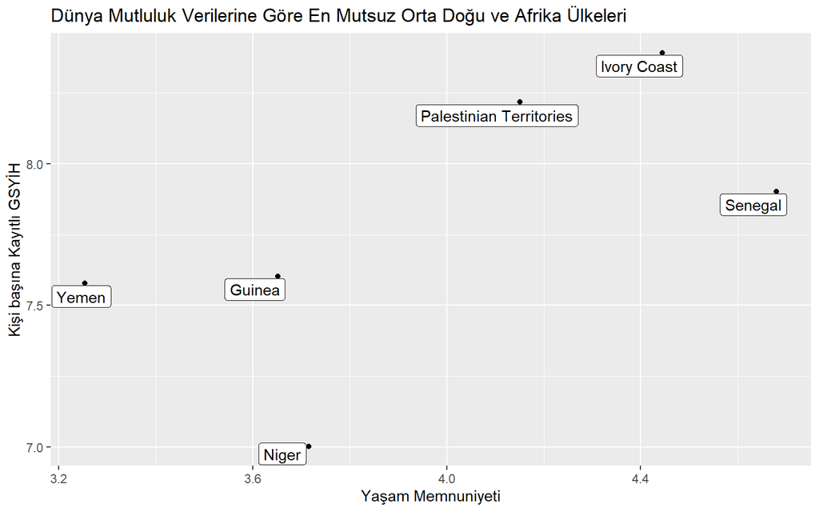

```r
p3 <-ggplot(data = data %>%
             filter(Country_name==c("Yemen","Egypt","Jordan","Palestinian Territories","Lebanon","Tunisia","Iran","Iraq","Algeria","Morocco", "Turkey","Libya","Kuwait","Saudi Arabia", "United Arab Emirates","Bahrain","Israel","Guinea","Niger","Gambia", "Benin","Mauritius","Congo (Brazzaville)", "Ivory Coast","Cameroon","Senegal","Ghana") & Life_Ladder<5))+
  geom_point(mapping = aes(x=Life_Ladder,
                           y=Log_GDP_per_capita))+
  ggtitle("Dünya Mutluluk Verilerine Göre En Mutsuz Orta Doğu ve Afrika Ülkeleri")+
  xlab("Yaşam Memnuniyeti")+
  ylab("Kişi başına Kayıtlı GSYİH")+
  geom_label_repel(aes(x=Life_Ladder,
                       y=Log_GDP_per_capita,
                       label=Country_name),
                   box.padding = 0.05,
                   point.padding = 0.1,
                   max.overlaps = 30,
                   segment.color = 'grey50')
p3
```

Hem histogram hemde saçılım grafiğini öğrendiğimize göre bu ikisini birleştirerek daha farklı bir grafiksel gösterim elde edebiliriz.

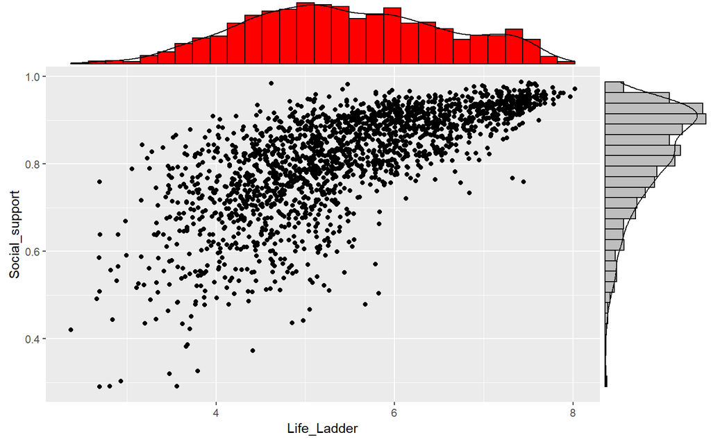

```r
d2 <- ggplot(data, aes(x = Life_Ladder, y = Social_support)) +
  geom_point()
ggMarginal(d2, type = "densigram",
           xparams = list(fill = 2),
           yparams = list(fill = 8))
```

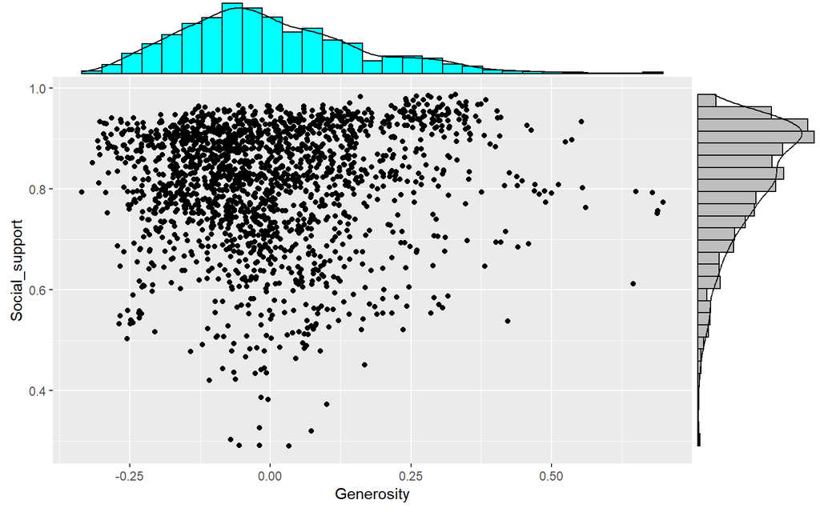

```r
d3 <- ggplot(data, aes(x = Generosity, y = Social_support)) +
  geom_point()
ggMarginal(d3, type = "densigram",
           xparams = list(fill = 5),
           yparams = list(fill = 8))
```

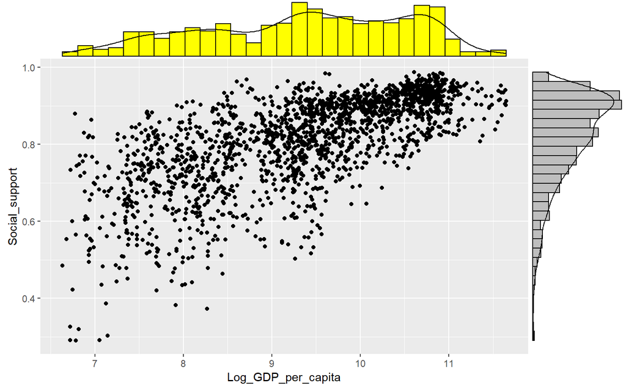

```r
d4 <- ggplot(data, aes(x = Log_GDP_per_capita, y = Social_support)) +
  geom_point()
ggMarginal(d4, type = "densigram",
           xparams = list(fill = 7),
           yparams = list(fill = 8))
```

## **2.3 KUTU GRAFİĞİ (BOX-PLOT)**

Bir kutu grafiği, veri çeyreklerini, yüzdelikleri, ortalamaları görüntüleyerek sayısal gözlemlerin görsel olarak dağılımını göstermek için kullanılır. Aynı zamanda aykırı değerlerin tespiti için de kullanılan bir grafiksel yöntemdir.

Kutu grafikleri, bir veri kümesinin beş özelliğini gösterir; * Minimum değer * İlk çeyreklik * Medyan * Üçüncü çeyreklik * Maksimum değer

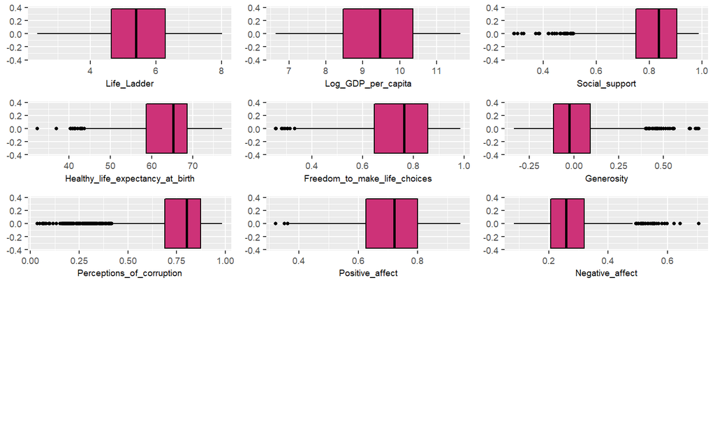

Çizdirdiğimiz kutu grafiklerini incelediğiniz zaman yukarıda bahsettiğimiz gibi hem çeyreklikler, hem medyan hem de aykırı gözlemler hakkında fikir sahibi olabiliyoruz.

## **2.4 ÇUBUK GRAFİĞİ (BAR-PLOT)**

Çubuk Grafiği, yatay veya düşey sütunları kullanarak kategoriler arası ayrım yapmaya ve sayısal karşılaştırmaları göstermeye yarar. Grafiğin bir ekseni, karşılaştırılan kategorileri, diğer ekseni ise bir değer ölçeğini gösterir.

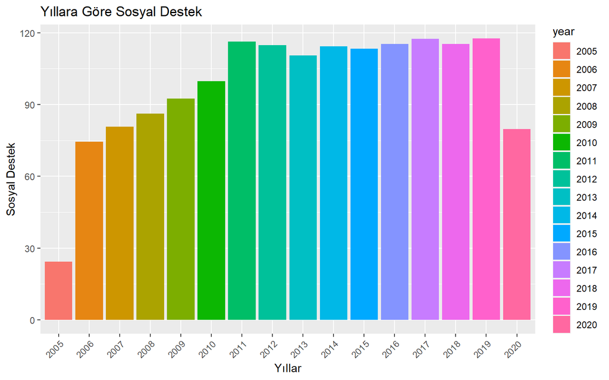

```r
ggplot(data, aes(x = year, y = Social_support, fill = year)) +
  geom_bar(stat = "identity")+
  theme(axis.text.x=element_text(angle=45, hjust=1))+
  labs(title = "Yıllara Göre Sosyal Destek") +
  ylab("Sosyal Destek")+
  xlab("Yıllar")
```